# Orsntein Model 1. mean=0 theta=1

# $h_{n+1} = h_n + \theta (\mu - h_n)dt + \sigma \sqrt{dt} \epsilon_{n+1}$ with $\epsilon_{n+1} \sim N(0,1)$

# $x_{n+1}= h_{n+1}-h_n$

We estimate the probabilities for $x_{n+1}$ to belong to some arbitrary buckets, based on the observations $(x_1,x_2, \cdots, x_n)$.

The estimation is done by comparing the probabilities predicted by the model for the buckets to the one-hot encoding $y_h$ of the bucket of $x_{n+1}$

We compare these predicted probabilities to the the target probability $p_j(x_{n+1}|h_n,model)$ for the bucket $B_j$.

The $(h_1, \cdots, h_{n+1})$ are simulated with $h_0=\mu$ and from them the $(x_1,x_2, \cdots, x_{n+1})$ \

dataset is the family of the sequences $(x_1,x_1, \cdots, x_{n+1})$

We simulate 4291 sequences

If $\theta=0$ we find the same results as in the pure normal model (model3) with the same seed.

Attention "Shuffle= False" for replication but is not recommended to estimate

https://kazemnejad.com/blog/transformer_architecture_positional_encoding/

For reproductibility (model 3= model8)

1. fixed seeds
2. kernel initializers
3. no shuffle in the optimizer

https://colab.research.google.com/notebooks/pro.ipynb

Your resources are not unlimited in Colab. To make the most of Colab, avoid using resources when you don't need them. For example, only use a GPU when required and close Colab tabs when finished.

# Libraries and Models

```python
import numpy as np
from scipy.stats import norm
from sklearn.preprocessing import OneHotEncoder
import tensorflow as tf
from tensorflow import keras
from tensorflow.keras import layers, initializers
from tensorflow.keras.layers import Input, MultiHeadAttention
from tensorflow.keras.models import Model
import matplotlib.pyplot as plt
from keras.callbacks import Callback
```

# Data Generation

```python
############# Input parameters  ################################################
seed=1
np.random.seed(seed)
tf.random.set_seed(seed)

mean = 0                 # mean parameter for the (h_i)
theta = 1                 # mean-reversion coefficient
sigma = 1                 # standard deviation GT modif
std=sigma
dt = 1
#dt= 1/255                    # time step for Orsntein Uhlenbeck
n_buckets = 7             # number of buckets
n_classes = n_buckets
seq_length = 5          # length of the (x_i) sequence used for prediction
nb_total = 4291           # number of trajectories to generate
nb_train = 3601          # number of trajectories for training
pe =1                     # pe=1 for positional encoding, otherwise 0

################# Data generation ##############################################
def ornstein_uhlenbeck(dt, num_steps, num_trajectories, mean, theta, sigma):
    h = np.zeros((num_steps, num_trajectories))
    h[0, :] = mean
    for t in range(1, num_steps):
        dh = theta * (mean - h[t-1, :]) * dt + sigma * np.sqrt(dt) * np.random.normal(size=(num_trajectories,))
        h[t, :] = h[t-1, :] + dh
    return h

def new_ornstein_uhlenbeck(dt, num_steps, num_trajectories, mean, theta, sigma):
    x=np.zeros((num_steps, num_trajectories))
    sqrtdt=np.sqrt(dt)
    x[0, :] = mean
    for jj in range(num_steps-1):
        x[jj+1, :] = x[jj,:] + theta*(mean - x[jj, :])*dt + sigma*sqrtdt*np.random.randn(num_trajectories)
    return x

trajectories = ornstein_uhlenbeck(dt, seq_length+2, nb_total, mean, theta, sigma)
trajectories2 = ornstein_uhlenbeck(dt, int(1/dt), nb_total, mean, theta, sigma)
trajectories2 = ornstein_uhlenbeck(dt, seq_length+2, nb_total, mean, theta, sigma)
trajectories = trajectories2[-(seq_length+2):,:]# GT modif
dataseto = np.diff(trajectories, axis=0)
dataseto[0,:]=trajectories[0,:]#GT modif
#dataset=dataseto.reshape(dataseto.shape[1],dataseto.shape[0],1)
dataset=(dataseto.T).copy()#transpose
dataset=dataset[:,:,None]#add one dimension
```

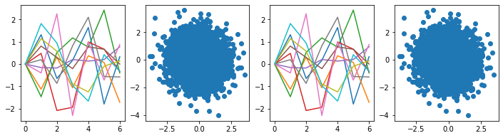

```python
if(True):#debug only GT modif
    plt.figure('ou plot',figsize=(4*3,3))
    plt.subplot(1,4,1)
    plt.plot(trajectories[:,:10])
    plt.subplot(1,4,2)
    plt.scatter(trajectories[-2,:],trajectories[-1,:])

    plt.subplot(1,4,3)
    plt.plot(trajectories2[:,:10])
    plt.subplot(1,4,4)
    plt.scatter(trajectories2[-2,:],trajectories2[-1,:])
```

```python
################## Position encoding for (x_1,...x_n) ##########################
def get_positional_encoding(seq_length, input_dim):
    position = np.arange(seq_length)[:, np.newaxis]
    div_term = np.exp(np.arange(0, input_dim, 2) * -(np.log(10000.0) / input_dim))
    positional_encoding = np.zeros((seq_length, input_dim))
    positional_encoding[:, 0::2] = np.sin(position * div_term)
    positional_encoding[:, 1::2] = np.cos(position * div_term)
    return positional_encoding

input_dim = dataset.shape[2]
positional_encoding = get_positional_encoding(seq_length, input_dim)

################# train, validation and test sets ##############################
train_set = dataset[:nb_train,:,:] # indices (0,3600)
x_train= train_set[:,:seq_length,:]+ positional_encoding*pe
y_train= train_set[:,seq_length,:] # y=x_{n+1}

test_set = dataset[nb_train:,:,:] # indices (3601, end)
x_test= test_set[:,:seq_length,:]+ positional_encoding*pe
y_test= test_set[:,seq_length,:]
hidden = trajectories[-2,:] # extract h_n for each sequence

################# One hot Encoding of the x_{n+1} ##############################
echantillon = y_train  # Assuming this should be y_train
quantiles = np.percentile(echantillon, np.linspace(0, 100, n_classes + 1))
buckets = quantiles[1:-1]  # Defining the extremities of the buckets
encoder = OneHotEncoder(categories='auto')
encoder.fit(np.arange(1, n_classes + 1).reshape(-1, 1))

def update_bucket(y):
    bucket = np.ones_like(y)
    for j in range(y.shape[0]):
        for i in range(len(buckets)):
            if y[j] > buckets[i]:
                bucket[j] += 1
    bucket_encoded = encoder.transform(bucket.reshape(-1, 1))
    bucket_encoded_dense = bucket_encoded.toarray()
    return bucket_encoded_dense

yh_test = update_bucket(y_test)
yh_train = update_bucket(y_train)
```

```python
dataset.shape,nb_train, dataset[:nb_train,:,:].shape,test_set.shape, train_set[12,seq_length,:],train_set[12,-1,:]
```

```
((4291, 6, 1),
 3601,
 (3601, 6, 1),
 (690, 6, 1),
 array([-1.37908911]),
 array([-1.37908911]))
```

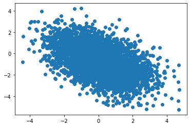

```python
plt.scatter(x_train[:,-2,0],x_train[:,-1,0])
```

```
(0.004603860726345346,
 0.011161597647578432,
 array([515., 514., 514., 515., 514., 514., 515.]),
 array([102., 101., 101.,  78., 115.,  88., 105.]),
 array([-1.5479577 , -0.80670365, -0.25563457,  0.26803618,  0.80969967,
         1.5339966 ]),
 array([-1.5627276 , -0.85904886, -0.30205722,  0.34134502,  0.79836054,
         1.56827421]),
 array([-4.44472201, -3.88288979, -3.61015139, -3.52828632, -3.45739792,
        -3.37985013, -3.29411496]),
 array([-3.70843862, -3.5403157 , -3.28413025, -3.24036306, -3.09373415,
        -3.06825096, -3.06236183]),
 ' traj2',
 array([-4.34645412, -3.77569145, -3.59824096, -3.51079371, -3.4352208 ,
        -3.30901424, -3.28211322]),
 -5.54744557087057,
 6.463217835967607,
 -3.774340569448924,
 5.389314722232845)
```

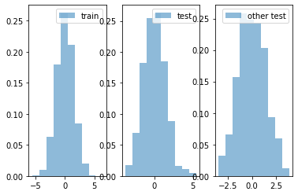

```python
#plt.hist(y_test)
#buckets
plt.figure('hist')
plt.subplot(1,3,1)
plt.hist(y_train,alpha=0.5,density=True)
plt.legend(['train'])
plt.subplot(1,3,2)
plt.hist(y_test,alpha=0.5,density=True)
#plt.hist(trajectories2[-1,:]-trajectories2[-2,:],alpha=0.5,density=True)
plt.legend(['test'])
plt.subplot(1,3,3)#now take choice at random
plt.hist(dataset[np.random.choice(dataset.shape[0],y_test.shape[0]),-1,0],alpha=0.5,density=True)
plt.legend(['other test'])

(np.mean(y_train),np.mean(y_test),
np.sum(yh_train,axis=0),np.sum(yh_test,axis=0),
buckets,np.percentile(y_test, np.linspace(0, 100, n_classes + 1))[1:-1],
np.percentile(y_train, [(jj+1)/n_classes for jj in range(n_classes)]),
np.percentile(y_test, [(jj+1)/n_classes for jj in range(n_classes)]),
 ' traj2',
np.percentile(trajectories2[-1,:]-trajectories2[-2,:], [(jj+1)/n_classes for jj in range(n_classes)]),
 np.min(y_train),np.max(y_train), np.min(y_test),np.max(y_test),
)
```

# Model Build and Compile

```python
###################### Parameters #####################################
head_size=256               # will be the dimension of : the query, key and value vectors for each head
num_heads=4                 # total hidden dimension is 256*4 = 1024
ff_dim=4                    # number of filters in the FeedForward Layer
num_transformer_blocks=4    # Nb of iterations of the Encoder block
mlp_units=[128]             # list of the number of units of the final "dense layers" - just one with 128 neurons
mlp_units=[10]             # list of the number of units of the final "dense layers" - just one with 128 neurons GT modif
mlp_dropout=0.4             # frequency of dropout for the dropout layers
mlp_dropout=0.0             # frequency of dropout for the dropout layers GT modif
dropout=0.25                # frequency of dropout inside the MultiHEad Attention
input_shape = x_train.shape[1:] # (500,1)

# Definition of the Encoder Block
def transformer_encoder(inputs, head_size, num_heads, ff_dim, dropout=0):
    # Normalization batch by batch and affine parameters to learn
    x = layers.LayerNormalization(epsilon=1e-6)(inputs)
    x = layers.MultiHeadAttention(key_dim=head_size, num_heads=num_heads, dropout=dropout)(x, x)
    x = layers.Dropout(dropout)(x)
#    res = x + inputs
    res = x + inputs

    # Feed Forward Part
    x = layers.LayerNormalization(epsilon=1e-6)(res)
    x = layers.Conv1D(filters=ff_dim, kernel_size=1, activation="relu", kernel_initializer=initializers.RandomNormal(seed=seed))(x)
    x = layers.Dropout(dropout)(x)
    x = layers.Conv1D(filters=inputs.shape[-1], kernel_size=1, kernel_initializer=initializers.RandomNormal(seed=seed))(x)
    return x + res

def build_model(
    input_shape,
    head_size,
    num_heads,
    ff_dim,
    num_transformer_blocks,
    mlp_units,
    dropout=0,
    mlp_dropout=0,
):
    inputs = keras.Input(shape=input_shape)
    x = inputs
    for _ in range(num_transformer_blocks):
        x = transformer_encoder(x, head_size, num_heads, ff_dim, dropout)

    x = layers.GlobalAveragePooling1D(data_format="channels_first")(x)
    for dim in mlp_units:
        x = layers.Dense(dim, activation="relu", kernel_initializer=initializers.RandomNormal(seed=seed))(x)
        x = layers.Dropout(mlp_dropout)(x)
    outputs = layers.Dense(n_buckets, activation="softmax", kernel_initializer=initializers.RandomNormal(seed=seed))(x)
    return keras.Model(inputs, outputs)

def build_model_fc(input_shape,head_size,num_heads,ff_dim,
    num_transformer_blocks, mlp_units, dropout=0,mlp_dropout=0):
    inputs = keras.Input(shape=(input_shape[0],))
    x = inputs
    for _ in range(num_transformer_blocks):#GT modif
      for dim in mlp_units:
        x = layers.Dense(dim, activation="relu", kernel_initializer=initializers.RandomNormal(seed=seed))(x)
    outputs = layers.Dense(n_buckets, activation="softmax", kernel_initializer=initializers.RandomNormal(seed=seed))(x)
    return keras.Model(inputs, outputs)



model = build_model(
    input_shape,              # (seq_length, d_model) here (500,1)
    head_size=head_size,      # dimension of the query key and value vectors
    num_heads=num_heads,      # usually 4
    ff_dim=ff_dim,            # number of filters in the feed forward
    num_transformer_blocks=num_transformer_blocks, # usually iteration of 4 encoders
    mlp_units=mlp_units,      # list of the final "dense layers" to add - just one with 128 neurons
    mlp_dropout=mlp_dropout,  # probability of dropout in the final dense lawyer of shape (None,128)
    dropout=0.25)             # probability of dropout in the attention score matrix and dropout layer of the Attention mechanism

model.compile(
    loss="categorical_crossentropy",
    optimizer=keras.optimizers.Adam(learning_rate=1e-3),
    metrics=["categorical_accuracy"])
#model.summary()
```

```python
model.summary()
```

```
Model: "model"
__________________________________________________________________________________________________
 Layer (type)                   Output Shape         Param #     Connected to
==================================================================================================
 input_1 (InputLayer)           [(None, 5, 1)]       0           []

 layer_normalization (LayerNorm  (None, 5, 1)        2           ['input_1[0][0]']
 alization)

 multi_head_attention (MultiHea  (None, 5, 1)        7169        ['layer_normalization[0][0]',
 dAttention)                                                      'layer_normalization[0][0]']

 dropout (Dropout)              (None, 5, 1)         0           ['multi_head_attention[0][0]']

 tf.__operators__.add (TFOpLamb  (None, 5, 1)        0           ['dropout[0][0]',
 da)                                                              'input_1[0][0]']

 layer_normalization_1 (LayerNo  (None, 5, 1)        2           ['tf.__operators__.add[0][0]']
 rmalization)

 conv1d (Conv1D)                (None, 5, 4)         8           ['layer_normalization_1[0][0]']

 dropout_1 (Dropout)            (None, 5, 4)         0           ['conv1d[0][0]']

 conv1d_1 (Conv1D)              (None, 5, 1)         5           ['dropout_1[0][0]']

 tf.__operators__.add_1 (TFOpLa  (None, 5, 1)        0           ['conv1d_1[0][0]',
 mbda)                                                            'tf.__operators__.add[0][0]']

 layer_normalization_2 (LayerNo  (None, 5, 1)        2           ['tf.__operators__.add_1[0][0]']
 rmalization)

 multi_head_attention_1 (MultiH  (None, 5, 1)        7169        ['layer_normalization_2[0][0]',
 eadAttention)                                                    'layer_normalization_2[0][0]']

 dropout_2 (Dropout)            (None, 5, 1)         0           ['multi_head_attention_1[0][0]']

 tf.__operators__.add_2 (TFOpLa  (None, 5, 1)        0           ['dropout_2[0][0]',
 mbda)                                                            'tf.__operators__.add_1[0][0]']

```

[output cut: 58 more lines]

```
 global_average_pooling1d (Glob  (None, 5)           0           ['tf.__operators__.add_7[0][0]']
 alAveragePooling1D)

 dense (Dense)                  (None, 10)           60          ['global_average_pooling1d[0][0]'
                                                                 ]

 dropout_8 (Dropout)            (None, 10)           0           ['dense[0][0]']

 dense_1 (Dense)                (None, 7)            77          ['dropout_8[0][0]']

==================================================================================================
Total params: 28,881
Trainable params: 28,881
Non-trainable params: 0
__________________________________________________________________________________________________
```

# Model Run

```python
# Restart after patience until total number of epochs
desired_epochs = 50# GT modif
patience =3
patience =10#GT modif
model_split =0.2
total_epochs = 0

callbacks = [
    keras.callbacks.EarlyStopping(patience=patience, restore_best_weights=True),
    # Add any other desired callbacks
    keras.callbacks.History()#GT modif
]

while total_epochs < desired_epochs:
    historical = model.fit(
        x_train,
        yh_train,
        validation_split=model_split,
        epochs=desired_epochs - total_epochs,
        batch_size=64,
        shuffle=True,
        callbacks=callbacks,
        verbose=1
    )
    if callbacks[0].stopped_epoch is not None:
        print("Early stopping occurred at epoch:", callbacks[0].stopped_epoch +1)
        #total_epochs += callbacks[0].stopped_epoch + 1  # Increment total epochs with early stopping epoch
        total_epochs=len(model.history.history['val_loss'])#GT modif
        print("total_epochs so far",total_epochs)
    else:
        total_epochs = desired_epochs  # Reached desired epochs without early stopping
```

```
Early stopping occurred at epoch: 1
total_epochs so far 50
```

# Checking and Analyzing the Results

### Calculating the target and predicted probabilities

```python
##### Calculating the target probabilities p_j(x_{n+1}|h_n) for each trajectory
coeff=sigma*np.sqrt(dt)
def calculate_proba(buckets, hidden_states): #hidden_states will be a np of the h_n
    result = []
    for c in hidden_states:
        new_array = (buckets - theta*(mean-c))/coeff
        cdf_values = norm.cdf(new_array)
        cdf_values = np.insert(cdf_values, [0, len(cdf_values)], [0, 1])
        differences = np.diff(cdf_values)
        result.append(differences)
    result=np.vstack(result)
    return result

p_target =calculate_proba(buckets, hidden)
p_target_train = p_target[:nb_train,:]
p_target_test =p_target[nb_train:,:]

#### Calculating the predicted probabilities p_j(x_{n+1}|x_1,..,x_n) for each trajectory
pred_test=model.predict(x_test)
mean_pred_test = np.mean(pred_test, axis=0)
pred_train=model.predict(x_train)
mean_pred_train = np.mean(pred_train, axis=0)
###### model evaluation ########################################################
model.evaluate(x_test, yh_test, verbose=1)
```

```
[1.7261608839035034, 0.28985506296157837]
```

### Average Cross Entropy between two families of distribution

The cross entropy $H(P,Q)$ where $P$ is the reference probability is defined as $$H(P,Q)=-\sum\limits_{i=1}^n p_iln(q_i)\geq H(P,P)$$

When there rare two families of probabilities $F_P=\{P^j\}$ and $F_Q=\{Q^j\}$ we calculate the average cross entropy as $$H(F_P,F_Q) = \frac{1}{m}\sum\limits_{j=1}^m H(P^j,Q^j)\geq H(F_P,F_P)$$

```python
############### analysing the cross entropies numbers ##########################
def individual_cross_entropies(family1, family2):
    n = family1.shape[0]  # Number of distributions in each family
    cross_entropies = np.zeros(n)

    for i in range(n):
        cross_entropy = -np.sum(family1[i] * np.log(family2[i]))
        cross_entropies[i] = cross_entropy
    return cross_entropies

###### target average_loss on train_set
z_1=np.mean(individual_cross_entropies(yh_train,p_target_train))
z_2=np.mean(individual_cross_entropies(yh_train,pred_train))
print('ideal loss on train_set:',z_1 )
print('loss obtained on train_set:',z_2 )
###### target average_loss on test_set
z_1=np.mean(individual_cross_entropies(p_target_test,p_target_test))
z_2=np.mean(individual_cross_entropies(p_target_test,pred_test))
print('ideal loss on test_set:',z_1 )
print('loss obtained on test_set:',z_2 )
```

```
ideal loss on train_set: 1.606546799141291
loss obtained on train_set: 1.6949231457922136
ideal loss on test_set: 1.6159212836579495
loss obtained on test_set: 1.7048638754808851
```

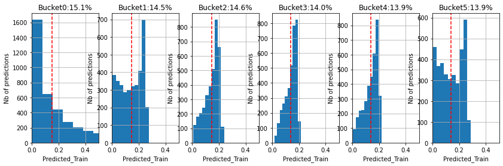

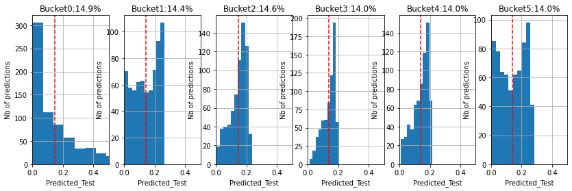

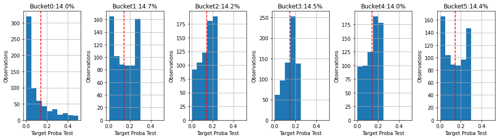

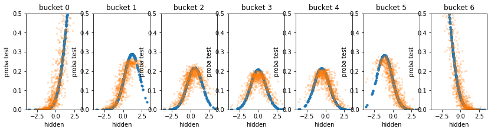

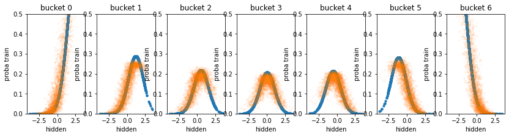

```python
########### visualisation predicted proba on train_set #########################
fig, axes = plt.subplots(nrows=1, ncols=6, figsize=(14, 4))
pred_train_a=np.mean(pred_train,axis=0)
for i, ax in enumerate(axes.flat):
    ax.hist(pred_train[:, i], bins=10)
    ax.set_xlabel('Predicted_Train')
    ax.set_ylabel('Nb of predictions')
    ax.set_title('Bucket' + str(i))
    ax.set_title('Bucket'+str(i)+':'+str(np.round(100*pred_train_a[i],1))+'%')
    ax.grid(True)
    ax.set_xlim(0, 0.5)
    ax.axvline(x=pred_train_a[i], color='r', linestyle='--')
plt.show()

########### visualisation predicted proba on test_set ##########################
fig, axes = plt.subplots(nrows=1, ncols=6, figsize=(14, 4))
pred_test_a=np.mean(pred_test,axis=0)
for i, ax in enumerate(axes.flat):
    ax.hist(pred_test[:, i], bins=10)
    ax.set_xlabel('Predicted_Test')
    ax.set_ylabel('Nb of predictions')
    ax.set_title('Bucket' + str(i))
    ax.set_title('Bucket'+str(i)+':'+str(np.round(100*pred_test_a[i],1))+'%')
    ax.grid(True)
    ax.set_xlim(0, 0.5)
    ax.axvline(x=pred_test_a[i], color='r', linestyle='--')
plt.show()

########## visualisation target probabilities on test_set #####################
p_target_test=p_target[nb_train:,:]
p_target_test_a= np.average(p_target_test, axis=0)
fig, axes = plt.subplots(nrows=1, ncols=6, figsize=(14, 4))
for i, ax in enumerate(axes.flat):
    ax.hist(p_target_test[:, i], bins=10, range=(0, 0.5))
    ax.set_xlabel('Target Proba Test')
    ax.set_ylabel('Observations')
    ax.axvline(x=p_target_test_a[i], color='r', linestyle='--')
    ax.set_title('Bucket'+str(i)+':'+str(np.round(100*p_target_test_a[i],1))+'%')
    ax.grid(True)
plt.tight_layout()  # Ajuste automatiquement les espacements entre les sous-graphes
plt.show()

# Create a scatter plot for the test set
plt.figure("scatter",figsize=(14,3))
for jj in range(n_buckets):
  plt.subplot(1,n_buckets,jj+1)
  plt.scatter(hidden[nb_train:], p_target_test[:,jj],s=10)
  plt.scatter(hidden[nb_train:], pred_test[:,jj],s=5,alpha=0.2)
# Add labels and title
  plt.xlabel('hidden')
  plt.ylabel('proba test')
  plt.ylim(0, 0.5)
  plt.title('bucket '+ str(jj))
plt.show()

# Create a scatter plot for the train set
plt.figure("scatter",figsize=(14,3))
for jj in range(n_buckets):
  plt.subplot(1,n_buckets,jj+1)
  plt.scatter(hidden[:nb_train], p_target_train[:,jj],s=10)
  plt.scatter(hidden[:nb_train], pred_train[:,jj],s=5,alpha=0.05)
# Add labels and title
  plt.xlabel('hidden')
  plt.ylabel('proba train')
  plt.ylim(0, 0.5)
  plt.title('bucket '+ str(jj))
```

# Checking dimensions and Runs Data

```python
###################### Checking input data #####################################
print("dataset.shape, (x_1,...x_{n+1}) :",dataset.shape)
print("train_set.shape :",train_set.shape)
print("x_train.shape, sequences (x_1,..x_n) :",x_train.shape)
print("y_train.shape :",y_train.shape)
print("yh_train.shape :",yh_train.shape)
print("x_test.shape :",x_test.shape)
print("y_test.shape :",y_test.shape)
print("yh_test.shape :",yh_test.shape)
print("buckets :", buckets)
print("np.mean(yh_train,axis=0):", "\n",np.round(np.mean(yh_train,axis=0),4))
print("np.mean(yh_test,axis=0):", "\n",np.round(np.mean(yh_test,axis=0),4))

print("trajectories.shape, (h_0,...h_{n+1}) :",trajectories.shape)
print("positional_encoding.shape", positional_encoding.shape)
print("hidden.shape :",hidden.shape )
print("p_target.shape :",p_target.shape )
print("np.mean(p_target_train,axis=0):", "\n",np.round(np.mean(p_target_train,axis=0),4))
print("np.mean(p_target_test,axis=0):", "\n",np.round(np.mean(p_target_test,axis=0),4))

###############@ occurence of the buckets in the test_ data #####################
proba_test = np.mean(yh_test, axis=0)
proba_train = np.mean(yh_train, axis=0)
print("Occurence of the buckets in the train_set:", "\n",np.round(proba_train,3))
print("Occurence of the buckets in the test_set:","\n",np.round(proba_test,3))
print("average target proba per bucket:","\n",np.round(p_target_test_a,3))


#print(historical.history['loss'])
#print(historical.history['val_loss'])
#print(historical.history['categorical_accuracy'])
#print(historical.history['val_categorical_accuracy'])
```

```
dataset.shape, (x_1,...x_{n+1}) : (4291, 6, 1)
train_set.shape : (3601, 6, 1)
x_train.shape, sequences (x_1,..x_n) : (3601, 5, 1)
y_train.shape : (3601, 1)
yh_train.shape : (3601, 7)
x_test.shape : (690, 5, 1)
y_test.shape : (690, 1)
yh_test.shape : (690, 7)
buckets : [-1.5479577  -0.80670365 -0.25563457  0.26803618  0.80969967  1.5339966 ]
np.mean(yh_train,axis=0):
 [0.143  0.1427 0.1427 0.143  0.1427 0.1427 0.143 ]
np.mean(yh_test,axis=0):
 [0.1478 0.1464 0.1464 0.113  0.1667 0.1275 0.1522]
trajectories.shape, (h_0,...h_{n+1}) : (7, 4291)
positional_encoding.shape (5, 1)
hidden.shape : (4291,)
p_target.shape : (4291, 7)
np.mean(p_target_train,axis=0):
 [0.1369 0.1467 0.1434 0.1464 0.1411 0.1445 0.1409]
np.mean(p_target_test,axis=0):
 [0.1404 0.1465 0.1424 0.1451 0.1399 0.1435 0.1421]
Occurence of the buckets in the train_set:
 [0.143 0.143 0.143 0.143 0.143 0.143 0.143]
Occurence of the buckets in the test_set:
 [0.148 0.146 0.146 0.113 0.167 0.128 0.152]
average target proba per bucket:
 [0.14  0.147 0.142 0.145 0.14  0.144 0.142]
```